# Softening2

Tarrik Quneibi

7/20/2021

```r
library(tidyverse)
library(readxl)
library(ggplot2)
library(dplyr)
library(ggforce)
library(tidyquant)
library(patchwork)
library(gridBase)
library(cowplot)
```

Importing the data and reading the fike to a variable.

```r
##setwd("`/R code/softening/")
softening_file <- list.files(pattern = "2010")
file <- read.csv(softening_file)
```

This section cleans the data. Removes all NAs and empty cells. Converts all columns to their correct class. Combines the duplicate columns for hardness, calcium, and magnesium. Converts the calcium and magnesium columns to units of CaCO3. Removes all duplicate columns.

```r
file[is.na(file)] <- 0
file[file==""]<- 0

file[,4:35] <- sapply(file[,4:ncol(file)],as.numeric)
file[is.na(file)] <- 0
file$Collection.Date.Time <- as.POSIXct(file$Collection.Date.Time,format="%m/%d/%Y %H:%M",tz=Sys.timezone())
scada_data <- subset(file, subset = Location.description %in% c("Drinking Water SCADA Data"))
Flow_data <- cbind.data.frame(scada_data$Collection.Date.Time, scada_data$FLOW_SCADA_PLANT1_RIVER)
Flow_data <- cbind.data.frame(Flow_data, scada_data$FLOW_SCADA_PLANT1_WELL)
Flow_data <- cbind.data.frame(Flow_data,scada_data$FLOW_SCADA_PLANT2_RIVER)
Flow_data <- cbind.data.frame(Flow_data, scada_data$FLOW_SCADA_PLANT2_WELL)
colnames(Flow_data) <- c("Collection.Date.Time", "Plant 1 river", "Plant 1 well", "Plant 2 river", "Plant 2 well")
Flow_data$Total.Flow <- Flow_data$`Plant 1 river`+ Flow_data$`Plant 1 well` + Flow_data$`Plant 2 river` + Flow_data$`Plant 2 well`

file$Hardness <- file$X.DW_APC_SUB_Total.Hardness.by.2340B + file$HARDNESS
file$Calcium <- file$X.DW_APC_SUB_Calcium + file$CALCIUM+file$CHEM_SCADA_CA
file$Magnesium <- file$X.DW_APC_SUB_Magnesium + file$MAGNESIUM
file$Lime <- file$CHEM_SCADA_LIME_VA1 + file$CHEM_SCADA_LIME_VA2 + file$CHEM_SCADA_LIME_VA3 + file$CHEM_SCADA_LIME_VA4 + file$CHEM_SCADA_LIME_VA5
file <- left_join(file, Flow_data, by = "Collection.Date.Time")
file$Lime <- (file$Lime/(file$Total.Flow*8.34))
file$Calcium <- file$Calcium*2.48892
file$Magnesium <- file$Magnesium*4.11438

file$X.DW_APC_SUB_Total.Hardness.by.2340B <- NULL
file$HARDNESS <- NULL
file$X.DW_APC_SUB_Calcium <- NULL
file$CALCIUM <- NULL
file$CHEM_SCADA_CA <- NULL
file$X.DW_APC_SUB_Magnesium <- NULL
file$MAGNESIUM <- NULL
file$CHEM_SCADA_LIME_VA1 <-NULL
file$CHEM_SCADA_LIME_VA2 <-NULL
file$CHEM_SCADA_LIME_VA3 <-NULL
file$CHEM_SCADA_LIME_VA4 <-NULL
file$CHEM_SCADA_LIME_VA5 <-NULL
```

This chunk removes all extreme outliers from the pH and hardness data. anything aboce a pH of 14 and any hardness above 1000 mg/l CaCO3 are removed.

```r
i=0

##file[is.na(file)] <- 0
##file$Collection.Date.Time <- as.POSIXct(file$Collection.Date.Time, format="%m/%d/%Y %H:%M")
for (row in 1:nrow(file)) {
    Mag <- file[row, "Magnesium"]
    Date  <- as.POSIXct(file[row, "Collection.Date.Time"])

    if(Date <= as.POSIXct("2020-10-21 03:00:00")) {
       file[row, "Magnesium"] <- (file[row, "Magnesium"])/2.03204
    }
}

for (PH in file$PH){
  i=i+1
  if (PH > 14) {
    file$PH[i] <- NA
  ##file$PH[i] <- 0
  }
}

i=0
for (Hardness in file$Hardness){
  i=i+1
  if (Hardness > 1000){
    file$Hardness[i] <- NA
}
}
```

```r
scada_data <- subset(file, subset = Location.description %in% c("Drinking Water SCADA Data"))
raw_river <- subset(file, subset = Location.description %in% c("WTP Raw River"))
raw_well <- subset(file, subset = Location.description %in% c("WTP Raw Well  Combined"))

weighted <- left_join(raw_river, raw_well, by = "Collection.Date.Time")
weighted$Collection.Date.Time <- as.Date(weighted$Collection.Date.Time)
weighted <- left_join(weighted, Flow_data, by = "Collection.Date.Time")
weighted$Total.Hardness <- (weighted$Hardness.x*weighted$`Plant 1 river`+weighted$Hardness.x*weighted$`Plant 2 river`+weighted$Hardness.y*weighted$`Plant 1 well`+weighted$Hardness.y*weighted$`Plant 2 well`)/weighted$Total.Flow
weighted$Total.Calcium <- (weighted$Calcium.x*weighted$`Plant 1 river`+weighted$Calcium.x*weighted$`Plant 2 river`+weighted$Calcium.y*weighted$`Plant 1 well`+weighted$Calcium.y*weighted$`Plant 2 well`)/weighted$Total.Flow
weighted$Total.Magnesium <- (weighted$Magnesium.x*weighted$`Plant 1 river`+weighted$Magnesium.x*weighted$`Plant 2 river`+weighted$Magnesium.y*weighted$`Plant 1 well`+weighted$Magnesium.y*weighted$`Plant 2 well`)/weighted$Total.Flow
weighted$pH <- (weighted$PH.x*weighted$`Plant 1 river`+weighted$PH.x*weighted$`Plant 2 river`+weighted$PH.y*weighted$`Plant 1 well`+weighted$PH.y*weighted$`Plant 2 well`)/weighted$Total.Flow

raw_water <- weighted[, c("Collection.Date.Time", "Total.Hardness", "Total.Calcium", "Total.Magnesium", "pH")]
```

#Organizes the full data set into seperate dataframes based on the loccation. Converts all date columns to date time class.

```r
basin2 <- data.frame()
basin3 <- data.frame()
basin4 <- data.frame()
basin5 <- data.frame()
reservoir <- data.frame()

basin2 <- subset(file, subset = Location.description %in% c("WTP Plant1 Basin2"))
basin3 <- subset(file, subset = Location.description %in% c("WTP Plant1 Basin3" ))
basin4 <- subset(file, subset = Location.description %in% c("WTP Plant2 Basin4"))
basin5 <- subset(file, subset = Location.description %in% c("WTP Plant2 Basin5"))
reservoir <- subset(file, subset = Location.description %in% c("WTP Main Reservoir"))

basin2$Location.description <- "Basin2"
basin3$Location.description <- "Basin3"
basin4$Location.description <- "Basin4"
basin5$Location.description <- "Basin5"
reservoir$Location.description <- "Reservoir"
basin2$Collection.Date.Time <- as.POSIXct(basin2$Collection.Date.Time,format="%m/%d/%Y %H:%M",tz=Sys.timezone())
basin3$Collection.Date.Time <- as.POSIXct(basin3$Collection.Date.Time,format="%m/%d/%Y %H:%M",tz=Sys.timezone())
basin4$Collection.Date.Time <- as.POSIXct(basin4$Collection.Date.Time,format="%m/%d/%Y %H:%M",tz=Sys.timezone())
basin5$Collection.Date.Time <- as.POSIXct(basin5$Collection.Date.Time,format="%m/%d/%Y %H:%M",tz=Sys.timezone())
reservoir$Collection.Date.Time <- as.POSIXct(reservoir$Collection.Date.Time,format="%m/%d/%Y %H:%M",tz=Sys.timezone())
```

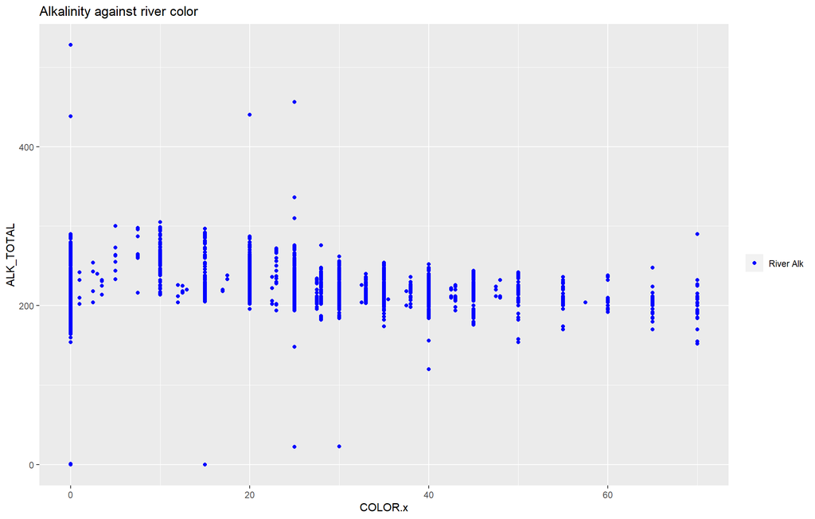

```r
river_alk <- subset(file, subset = Location.description %in% c("WTP Raw River"))
file.alk.b190 <- subset(river_alk, ALK_TOTAL < 190)
color_river <- subset(file, subset = Location.description %in% c("WTP Raw River"))
color_river$COLOR <- as.numeric(color_river$COLOR)
color_river <- cbind.data.frame(color_river$Collection.Date.Time, color_river$COLOR)
colnames(color_river) <- c("Collection.Date.Time", "COLOR")
river_alk$Collection.Date.Time <- as.POSIXct(river_alk$Collection.Date.Time,format="%m/%d/%Y %H:%M",tz=Sys.timezone())
color_river$Collection.Date.Time <- as.POSIXct(color_river$Collection.Date.Time,format="%m/%d/%Y %H:%M",tz=Sys.timezone())

alk_color <- left_join(river_alk, color_river, by = "Collection.Date.Time")

ggplot() +
    geom_point(data = alk_color, aes(x=COLOR.x, y = ALK_TOTAL, color='River Alk')) +
    scale_colour_manual("",
                      breaks = c("River Alk"),
                      values = c("blue")) +
   ggtitle("Alkalinity against river color")
```

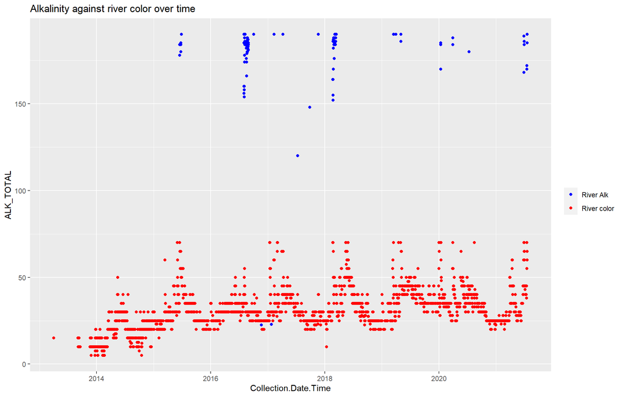

```r
ggplot() +
    geom_point(data = river_alk, aes(x=Collection.Date.Time, y = ALK_TOTAL, color='River Alk')) +
    geom_point(data = color_river, aes(x=Collection.Date.Time, y = COLOR, color='River color')) +
    scale_colour_manual("",
                      breaks = c("River Alk", "River color"),
                      values = c("blue", "red")) +
   ggtitle("Alkalinity against river color over time")+
  ylim(5,190)
```

The chunk below will have the data that is subset for the river alk<190 and river color>45. Each plot is broken up by the pound sign do that the plots dont get mixed up.

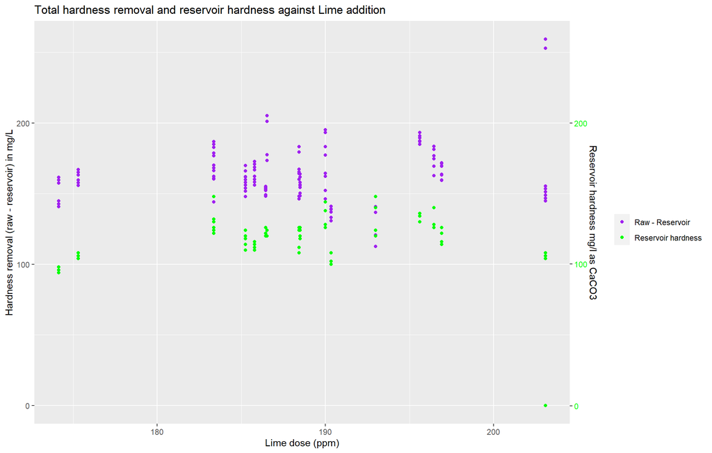

```r
river_alk <- subset(file, subset = Location.description %in% c("WTP Raw River"))
river_alk <- subset(river_alk, ALK_TOTAL < 190)
river_alk <- subset(river_alk, COLOR >45)
colnames(river_alk)[3] <- "Date"
river_alk$Date <- as.Date(river_alk$Date)
reservoir_diff <- cbind.data.frame(as.Date(reservoir$Collection.Date.Time, format = "%m/%d/%Y") ,reservoir$Hardness)
colnames(reservoir_diff) <- c("Date", "Hardness_Res")
Alk <- cbind.data.frame(as.Date(reservoir$Collection.Date.Time, format = "%m/%d/%Y") , reservoir$ALK_TOTAL)
colnames(Alk) <- c("Date", "Alkalinity")
raw_diff <- cbind.data.frame(as.Date(raw_water$Collection.Date.Time, format = "%m/%d/%Y") , raw_water$Total.Hardness)
colnames(raw_diff) <- c("Date", "Hardness_Raw")
Lime <- cbind.data.frame(as.Date(scada_data$Collection.Date.Time, format = "%m/%d/%Y") , scada_data$Lime)
colnames(Lime) <- c("Date", "Lime")
Color <- cbind.data.frame(as.Date(reservoir$Collection.Date.Time, format = "%m/%d/%Y") , reservoir$COLOR)
colnames(Color) <- c("Date", "Color")
basin_2diff <- cbind.data.frame(as.Date(basin2$Collection.Date.Time, format = "%m/%d/%Y") ,basin2$Hardness)
colnames(basin_2diff) <- c("Date", "Hardness_B2")
basin_3diff<- cbind.data.frame(as.Date(basin3$Collection.Date.Time, format = "%m/%d/%Y") ,basin3$Hardness)
colnames(basin_3diff) <- c("Date", "Hardness_B3")
basin_4diff<- cbind.data.frame(as.Date(basin4$Collection.Date.Time, format = "%m/%d/%Y") ,basin4$Hardness)
colnames(basin_4diff) <- c("Date", "Hardness_B4")
basin_5diff<- cbind.data.frame(as.Date(basin5$Collection.Date.Time, format = "%m/%d/%Y") ,basin5$Hardness)
colnames(basin_5diff) <- c("Date", "Hardness_B5")

###################################################################################################################################
data<- left_join(river_alk, reservoir_diff, by = "Date")
data1 <- left_join(data, raw_diff, by = "Date")
data2 <- left_join(data1, Lime, by = "Date")
data2$Difference <- data2$Hardness_Raw - data2$Hardness_Res
data2 <- data2[data2$ALK_TOTAL != 0, ]
data2 <- data2[data2$Hardness_Raw != 0, ]
data2$Date <- as.POSIXct(data2$Date)

ggplot() +
    geom_point(data = data2, aes(x=Lime.y, y = Difference, color='Raw - Reservoir')) +
    geom_point(data = data2, aes(x=Lime.y, y = Hardness_Res, color='Reservoir hardness')) +
    scale_colour_manual("",
                      breaks = c("Raw - Reservoir", "Reservoir hardness"),
                      values = c("purple", "green")) +
   ggtitle("Total hardness removal and reservoir hardness against Lime addition")+
  xlab("Lime dose (ppm)")+
  scale_y_continuous(
    "Hardness removal (raw - reservoir) in mg/L",
    sec.axis = sec_axis(~ . /1, name = "Reservoir hardness mg/l as CaCO3"))+
      theme(axis.text.y.right = element_text(color = "green"))
```

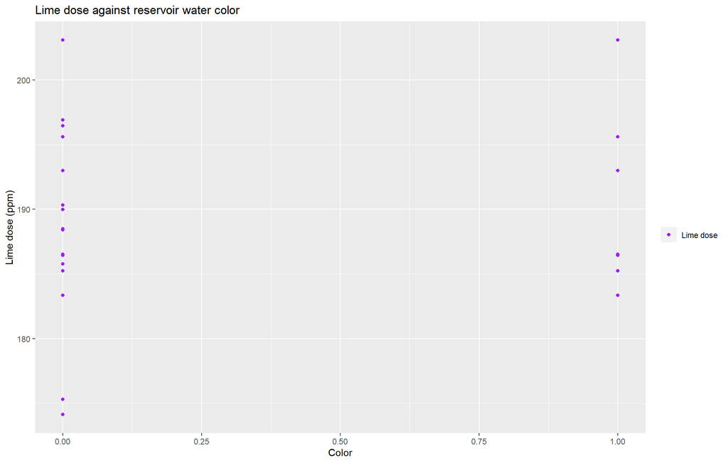

```r
###############################################################################################################################
data3 <- left_join(river_alk, Color, by = "Date")
data3 <- left_join(data3, Lime, by = "Date")
data3 <- data3[data3$ALK_TOTAL != 0, ]
data3$Date <- as.POSIXct(data3$Date)


ggplot() +
    geom_point(data = data3, aes(x=Color, y = Lime.y, color='Lime dose')) +
    scale_colour_manual("",
                      breaks = c("Lime dose"),
                      values = c("purple")) +
   ggtitle("Lime dose against reservoir water color")+
  xlab("Color")+
  ylab("Lime dose (ppm)")
```

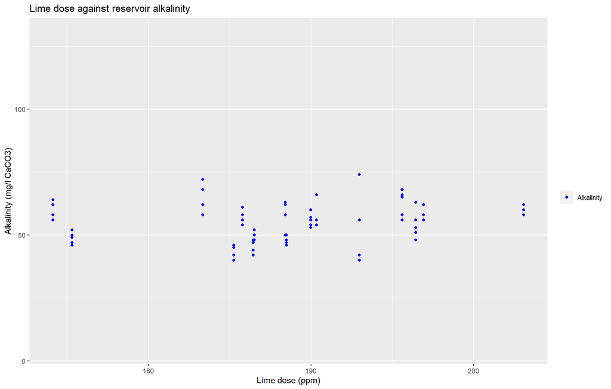

```r
################################################################################################################################
data4 <- left_join(river_alk, Alk, by = "Date")
data4 <- left_join(data4, Lime, by = "Date")
data4 <- data4[data4$ALK_TOTAL != 0, ]
data4$Date <- as.POSIXct(data4$Date)

ggplot() +
    geom_point(data = data4, aes(x=Lime.y, y = Alkalinity, color='Alkalinity')) +
    scale_colour_manual("",
                      breaks = c("Alkalinity"),
                      values = c("blue")) +
   ggtitle("Lime dose against reservoir alkalinity")+
  xlab("Lime dose (ppm)")+
  ylab("Alkalinity (mg/l CaCO3)")+
ylim(5,130)
```

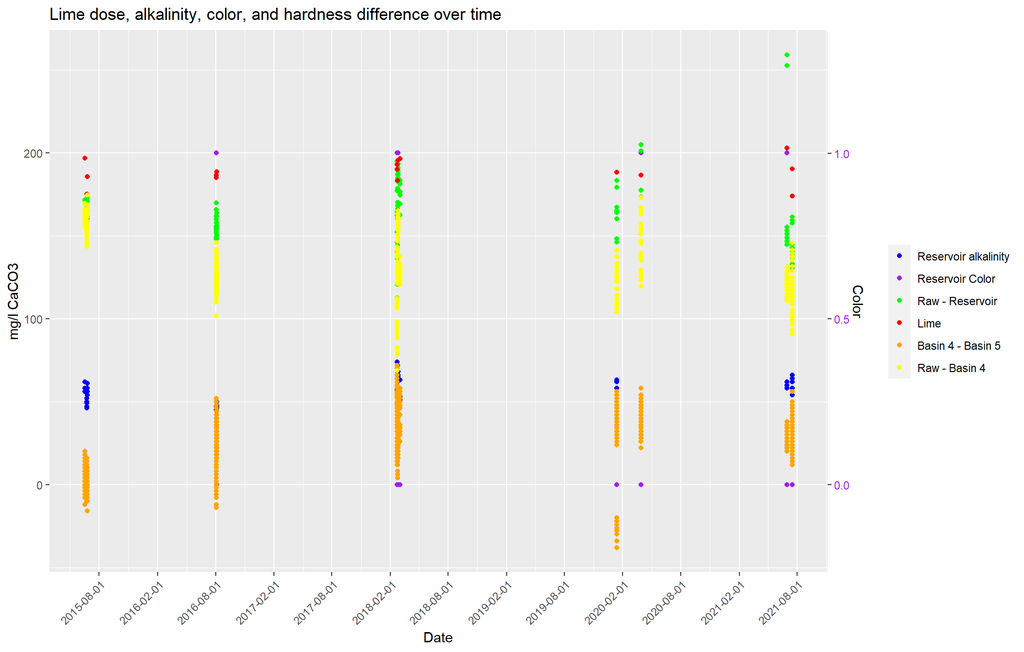

```r
################################################################################################################################
basin4_5 <- left_join(river_alk, basin_4diff, by = "Date")
basin4_5 <- left_join(basin4_5, basin_5diff, by = "Date")
basinR_4 <- left_join(river_alk, basin_4diff, by = "Date")
basinR_4 <- left_join(basinR_4, raw_diff, by = "Date")
basinR_4 <- basinR_4[basinR_4$Hardness_Raw != 0, ]
basin4_5$Difference <- basin4_5$Hardness_B4 - basin4_5$Hardness_B5
basinR_4$Difference <- basinR_4$Hardness_Raw - basinR_4$Hardness_B4

basin4_5$Date <- as.POSIXct(basin4_5$Date)
basinR_4$Date <- as.POSIXct(basinR_4$Date)

 ggplot() +
     geom_point(data = data4, aes(x=Date, y = Alkalinity, color='Reservoir alkalinity')) +
     geom_point(data = data3, aes(x=Date, y = Color*200, color='Reservoir Color')) +
     geom_point(data = data2, aes(x=Date, y = Difference, color='Raw - Reservoir')) +
     geom_point(data = data4, aes(x=Date, y = Lime.y, color='Lime')) +
     geom_point(data = basin4_5, aes(x=Date, y = Difference, color='Basin 4 - Basin 5')) +
     geom_point(data = basinR_4, aes(x=Date, y = Difference, color='Raw - Basin 4')) +
    scale_colour_manual("",
                      breaks = c("Reservoir alkalinity", "Reservoir Color", "Raw - Reservoir", "Lime", "Basin 4 - Basin 5", "Raw - Basin 4"),
                      values = c("blue", "purple", "green", "red","orange", "yellow")) +
   ggtitle("Lime dose, alkalinity, color, and hardness difference over time")+
  xlab("Date")+
  scale_y_continuous(
    "mg/l CaCO3",
    sec.axis = sec_axis(~ . /200, name = "Color"))+
      theme(axis.text.y.right = element_text(color = "purple"))+
  scale_x_datetime(date_breaks = "6 months")+
  theme(axis.text.x = element_text(angle = 45, vjust = 1, hjust=1))
```

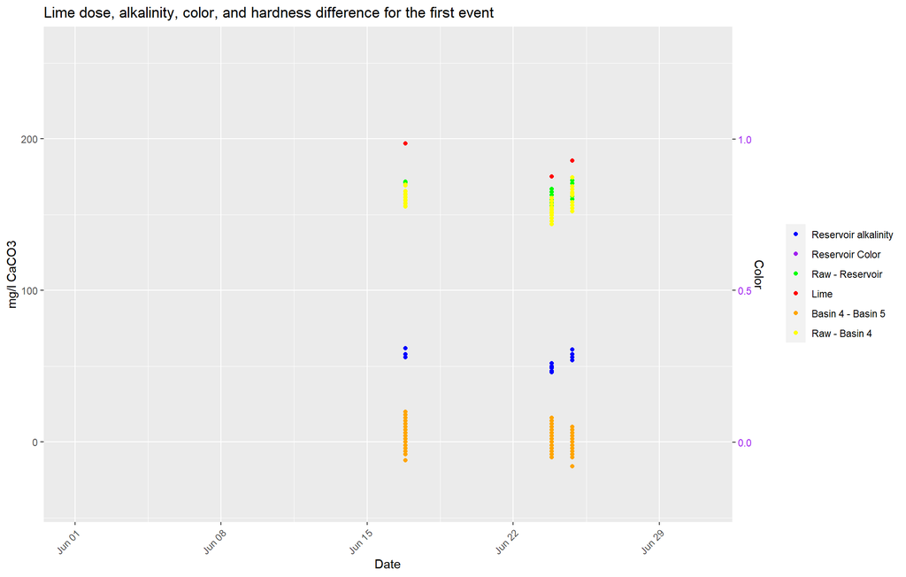

```r
 #############################################################################################for the first event
  ggplot() +
     geom_point(data = data4, aes(x=Date, y = Alkalinity, color='Reservoir alkalinity')) +
     geom_point(data = data3, aes(x=Date, y = Color*200, color='Reservoir Color')) +
     geom_point(data = data2, aes(x=Date, y = Difference, color='Raw - Reservoir')) +
     geom_point(data = data4, aes(x=Date, y = Lime.y, color='Lime')) +
     geom_point(data = basin4_5, aes(x=Date, y = Difference, color='Basin 4 - Basin 5')) +
     geom_point(data = basinR_4, aes(x=Date, y = Difference, color='Raw - Basin 4')) +
    scale_colour_manual("",
                      breaks = c("Reservoir alkalinity", "Reservoir Color", "Raw - Reservoir", "Lime", "Basin 4 - Basin 5", "Raw - Basin 4"),
                      values = c("blue", "purple", "green", "red","orange", "yellow")) +
   ggtitle("Lime dose, alkalinity, color, and hardness difference for the first event")+
  xlab("Date")+
  scale_y_continuous(
    "mg/l CaCO3",
    sec.axis = sec_axis(~ . /200, name = "Color"))+
      theme(axis.text.y.right = element_text(color = "purple"))+
  scale_x_datetime(date_breaks = "6 months")+
  theme(axis.text.x = element_text(angle = 45, vjust = 1, hjust=1))+
 xlim(as.POSIXct('2015-06-01'),as.POSIXct('2015-07-01'))
```

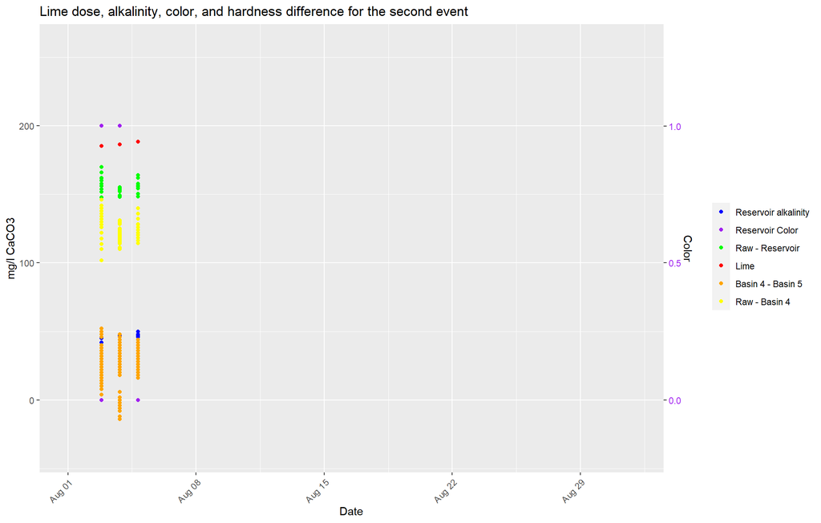

```r
 #############################################################################################for the second event
  ggplot() +
     geom_point(data = data4, aes(x=Date, y = Alkalinity, color='Reservoir alkalinity')) +
     geom_point(data = data3, aes(x=Date, y = Color*200, color='Reservoir Color')) +
     geom_point(data = data2, aes(x=Date, y = Difference, color='Raw - Reservoir')) +
     geom_point(data = data4, aes(x=Date, y = Lime.y, color='Lime')) +
     geom_point(data = basin4_5, aes(x=Date, y = Difference, color='Basin 4 - Basin 5')) +
     geom_point(data = basinR_4, aes(x=Date, y = Difference, color='Raw - Basin 4')) +
    scale_colour_manual("",
                      breaks = c("Reservoir alkalinity", "Reservoir Color", "Raw - Reservoir", "Lime", "Basin 4 - Basin 5", "Raw - Basin 4"),
                      values = c("blue", "purple", "green", "red","orange", "yellow")) +
   ggtitle("Lime dose, alkalinity, color, and hardness difference for the second event")+
  xlab("Date")+
  scale_y_continuous(
    "mg/l CaCO3",
    sec.axis = sec_axis(~ . /200, name = "Color"))+
      theme(axis.text.y.right = element_text(color = "purple"))+
  scale_x_datetime(date_breaks = "6 months")+
  theme(axis.text.x = element_text(angle = 45, vjust = 1, hjust=1))+
 xlim(as.POSIXct('2016-08-01'),as.POSIXct('2016-09-01'))
```

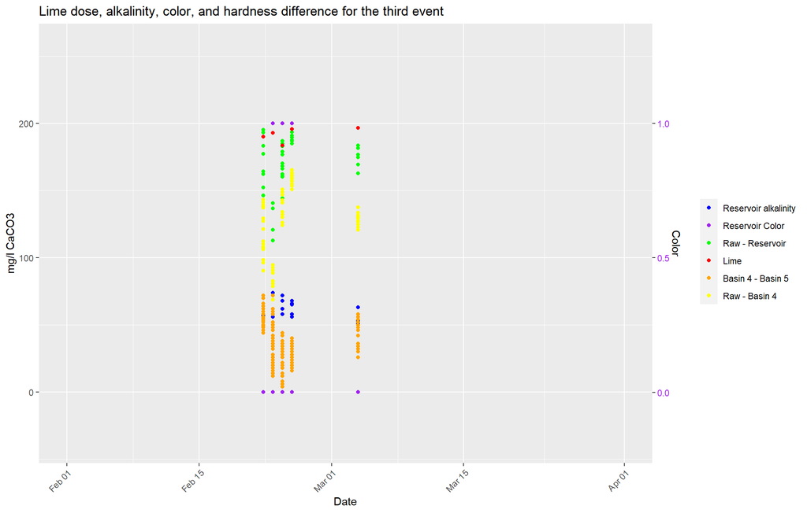

```r
 ###############################################################################################for the third event
  ggplot() +
     geom_point(data = data4, aes(x=Date, y = Alkalinity, color='Reservoir alkalinity')) +
     geom_point(data = data3, aes(x=Date, y = Color*200, color='Reservoir Color')) +
     geom_point(data = data2, aes(x=Date, y = Difference, color='Raw - Reservoir')) +
     geom_point(data = data4, aes(x=Date, y = Lime.y, color='Lime')) +
     geom_point(data = basin4_5, aes(x=Date, y = Difference, color='Basin 4 - Basin 5')) +
     geom_point(data = basinR_4, aes(x=Date, y = Difference, color='Raw - Basin 4')) +
    scale_colour_manual("",
                      breaks = c("Reservoir alkalinity", "Reservoir Color", "Raw - Reservoir", "Lime", "Basin 4 - Basin 5", "Raw - Basin 4"),
                      values = c("blue", "purple", "green", "red","orange", "yellow")) +
   ggtitle("Lime dose, alkalinity, color, and hardness difference for the third event")+
  xlab("Date")+
  scale_y_continuous(
    "mg/l CaCO3",
    sec.axis = sec_axis(~ . /200, name = "Color"))+
      theme(axis.text.y.right = element_text(color = "purple"))+
  scale_x_datetime(date_breaks = "6 months")+
  theme(axis.text.x = element_text(angle = 45, vjust = 1, hjust=1))+
 xlim(as.POSIXct('2018-02-01'),as.POSIXct('2018-04-01'))
```

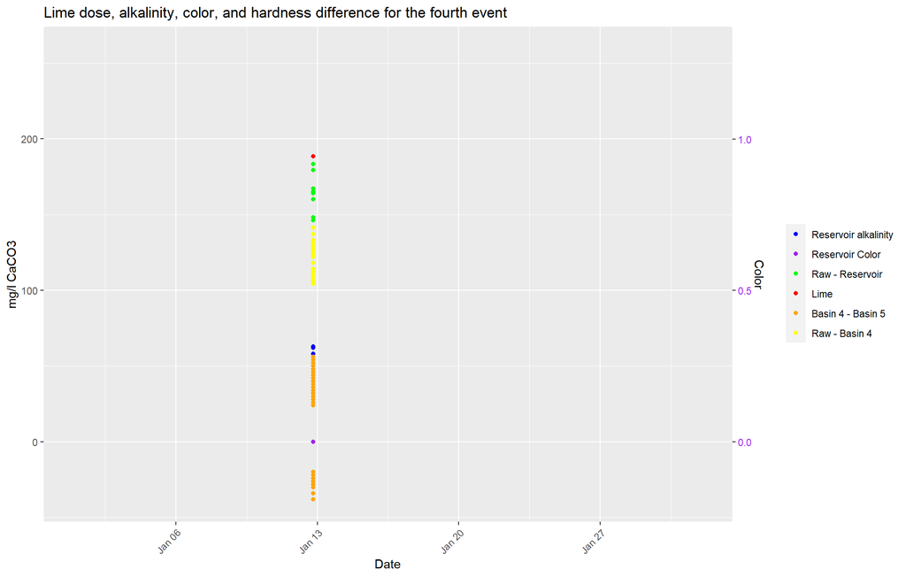

```r
 ###############################################################################################for the fourth event
  ggplot() +
     geom_point(data = data4, aes(x=Date, y = Alkalinity, color='Reservoir alkalinity')) +
     geom_point(data = data3, aes(x=Date, y = Color*200, color='Reservoir Color')) +
     geom_point(data = data2, aes(x=Date, y = Difference, color='Raw - Reservoir')) +
     geom_point(data = data4, aes(x=Date, y = Lime.y, color='Lime')) +
     geom_point(data = basin4_5, aes(x=Date, y = Difference, color='Basin 4 - Basin 5')) +
     geom_point(data = basinR_4, aes(x=Date, y = Difference, color='Raw - Basin 4')) +
    scale_colour_manual("",
                      breaks = c("Reservoir alkalinity", "Reservoir Color", "Raw - Reservoir", "Lime", "Basin 4 - Basin 5", "Raw - Basin 4"),
                      values = c("blue", "purple", "green", "red","orange", "yellow")) +
   ggtitle("Lime dose, alkalinity, color, and hardness difference for the fourth event")+
  xlab("Date")+
  scale_y_continuous(
    "mg/l CaCO3",
    sec.axis = sec_axis(~ . /200, name = "Color"))+
      theme(axis.text.y.right = element_text(color = "purple"))+
  scale_x_datetime(date_breaks = "6 months")+
  theme(axis.text.x = element_text(angle = 45, vjust = 1, hjust=1))+
 xlim(as.POSIXct('2020-01-01'),as.POSIXct('2020-02-01'))
```

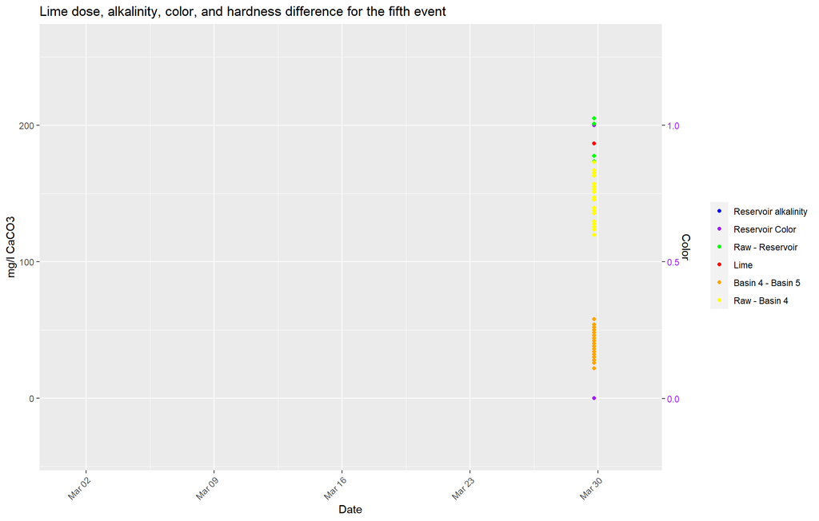

```r
 #############################################################################################for the fifth event
  ggplot() +
     geom_point(data = data4, aes(x=Date, y = Alkalinity, color='Reservoir alkalinity')) +
     geom_point(data = data3, aes(x=Date, y = Color*200, color='Reservoir Color')) +
     geom_point(data = data2, aes(x=Date, y = Difference, color='Raw - Reservoir')) +
     geom_point(data = data4, aes(x=Date, y = Lime.y, color='Lime')) +
     geom_point(data = basin4_5, aes(x=Date, y = Difference, color='Basin 4 - Basin 5')) +
     geom_point(data = basinR_4, aes(x=Date, y = Difference, color='Raw - Basin 4')) +
    scale_colour_manual("",
                      breaks = c("Reservoir alkalinity", "Reservoir Color", "Raw - Reservoir", "Lime", "Basin 4 - Basin 5", "Raw - Basin 4"),
                      values = c("blue", "purple", "green", "red","orange", "yellow")) +
   ggtitle("Lime dose, alkalinity, color, and hardness difference for the fifth event")+
  xlab("Date")+
  scale_y_continuous(
    "mg/l CaCO3",
    sec.axis = sec_axis(~ . /200, name = "Color"))+
      theme(axis.text.y.right = element_text(color = "purple"))+
  scale_x_datetime(date_breaks = "6 months")+
  theme(axis.text.x = element_text(angle = 45, vjust = 1, hjust=1))+
 xlim(as.POSIXct('2020-03-01'),as.POSIXct('2020-04-01'))
```

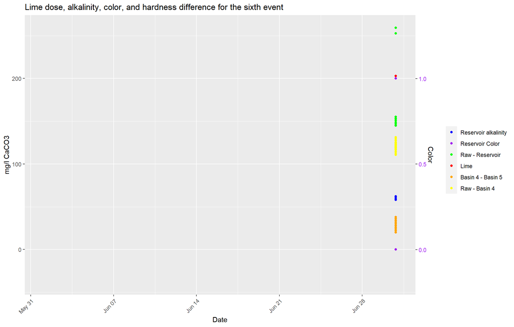

```r
 ###########################################################################################for the sixth event
  ggplot() +
     geom_point(data = data4, aes(x=Date, y = Alkalinity, color='Reservoir alkalinity')) +
     geom_point(data = data3, aes(x=Date, y = Color*200, color='Reservoir Color')) +
     geom_point(data = data2, aes(x=Date, y = Difference, color='Raw - Reservoir')) +
     geom_point(data = data4, aes(x=Date, y = Lime.y, color='Lime')) +
     geom_point(data = basin4_5, aes(x=Date, y = Difference, color='Basin 4 - Basin 5')) +
     geom_point(data = basinR_4, aes(x=Date, y = Difference, color='Raw - Basin 4')) +
    scale_colour_manual("",
                      breaks = c("Reservoir alkalinity", "Reservoir Color", "Raw - Reservoir", "Lime", "Basin 4 - Basin 5", "Raw - Basin 4"),
                      values = c("blue", "purple", "green", "red","orange", "yellow")) +
   ggtitle("Lime dose, alkalinity, color, and hardness difference for the sixth event")+
  xlab("Date")+
  scale_y_continuous(
    "mg/l CaCO3",
    sec.axis = sec_axis(~ . /200, name = "Color"))+
      theme(axis.text.y.right = element_text(color = "purple"))+
  scale_x_datetime(date_breaks = "6 months")+
  theme(axis.text.x = element_text(angle = 45, vjust = 1, hjust=1))+
 xlim(as.POSIXct('2021-06-01'),as.POSIXct('2021-07-01'))
```

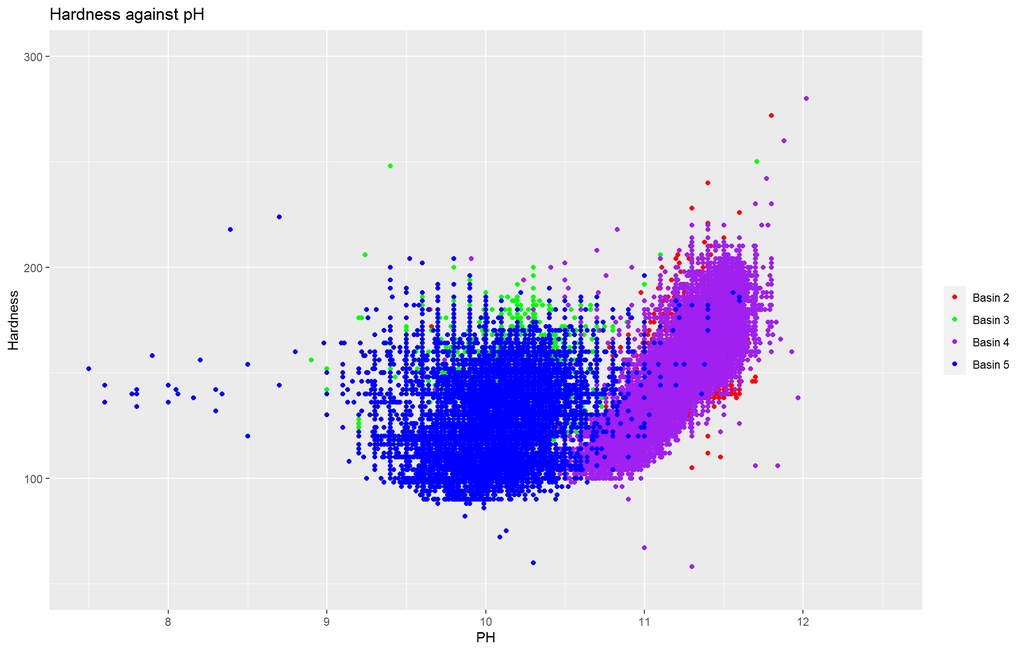

```r
ggplot() +
    geom_point(data = basin2, aes(x=PH, y = Hardness, color='Basin 2')) +
    geom_point(data = basin3, aes(x=PH, y = Hardness, color='Basin 3')) +
    geom_point(data = basin4, aes(x=PH, y = Hardness, color='Basin 4')) +
    geom_point(data = basin5, aes(x=PH, y = Hardness, color='Basin 5')) +
    scale_colour_manual("",
                      breaks = c("Basin 2", "Basin 3", "Basin 4", "Basin 5"),
                      values = c("red", "green", "purple", "blue")) +
   ggtitle("Hardness against pH")+
   xlim(7.5 , 12.5)+
   ylim(50, 300)
```

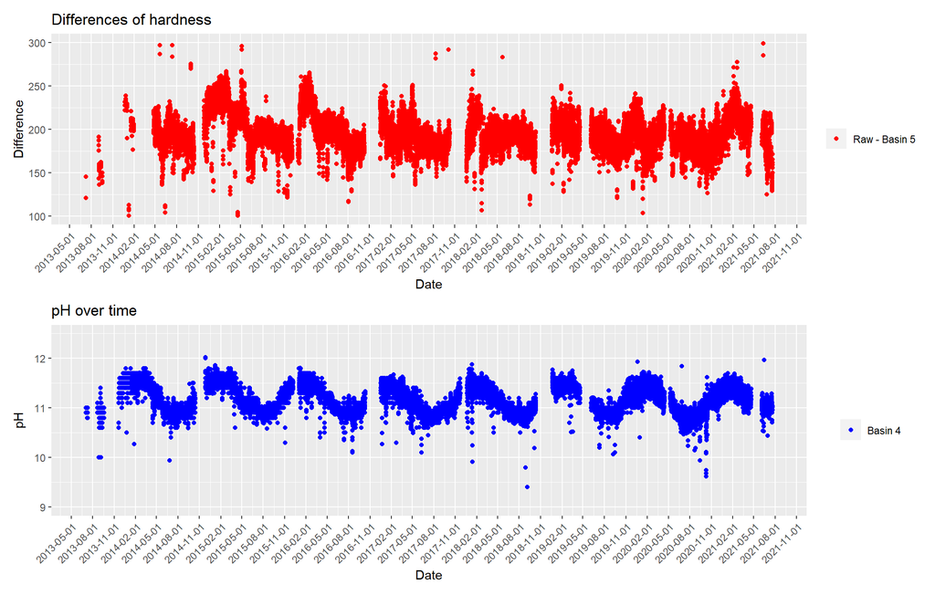

```r
#############################################################################################
Basin_4 <- cbind.data.frame(as.Date(basin4$Collection.Date.Time, format = "%m/%d/%Y"), basin4$PH)
colnames(Basin_4) <- c("Date", "pH_B4")
Basin_5 <- cbind.data.frame(as.Date(basin5$Collection.Date.Time, format = "%m/%d/%Y"), basin5$Hardness)
colnames(Basin_5) <- c("Date", "Hardness_B5")
Raw <- cbind.data.frame(as.POSIXct(raw_water$Collection.Date.Time,format = "%m/%d/%Y"), raw_water$Total.Hardness)
colnames(Raw) <- c("Date", "Hardness_R")

data1 <- left_join(Basin_5, Raw, by = "Date")
data1 <- left_join(data1, Basin_4, by= "Date")
data1[data1 == 0] <- NA
data1 <- data1[complete.cases(data1), ]

data1$Difference <- data1$Hardness_R - data1$Hardness_B5
#############################################################################################
plot1<-  ggplot() +
  geom_point(data = data1, aes(x = Date, y = Difference, color = "Raw - Basin 5")) +
  scale_colour_manual("",
                      breaks = c("Raw - Basin 5"),
                      values = c("red")) +
  theme(axis.text.x = element_text(angle = 45, vjust = 1, hjust=1))+
  scale_x_datetime(date_breaks = "3 months")+
  xlab('Date') +
  ggtitle('Differences of hardness')+
  ylim(100, 300)


plot2<- ggplot() +
  geom_point(data = basin4, aes(x = Collection.Date.Time, y = PH, color = "Basin 4")) +
  scale_colour_manual("",
                      breaks = c("Basin 4"),
                      values = c("blue")) +
  theme(axis.text.x = element_text(angle = 45, vjust = 1, hjust=1))+
  xlab('Date') +
  ylab('pH')+
  ylim(9,12.5)+
  ggtitle('pH over time')+
  scale_x_datetime(date_breaks = "3 months")

plot1/plot2
```

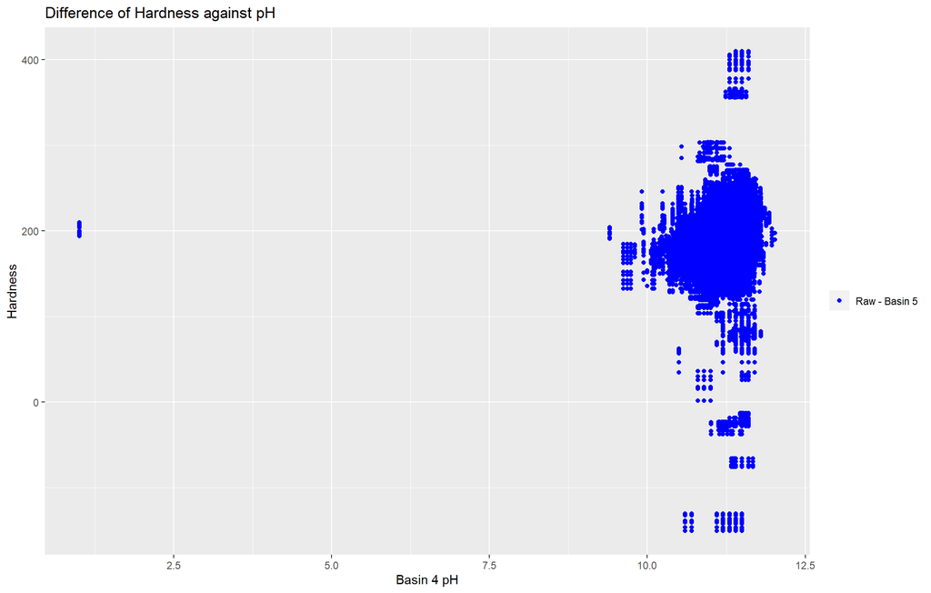

```r
################################################################################################
ggplot() +
    geom_point(data = data1, aes(x=pH_B4, y = Difference, color='Raw - Basin 5')) +
    scale_colour_manual("",
                      breaks = c("Raw - Basin 5"),
                      values = c("blue")) +
   ggtitle("Difference of Hardness against pH")+
   xlab("Basin 4 pH")+
   ylab("Hardness")
```

This plots all locations magnesium and calium concentrations against the pH. The last section plots the magnesium removed by basins 2 and 4 against their respective pH.

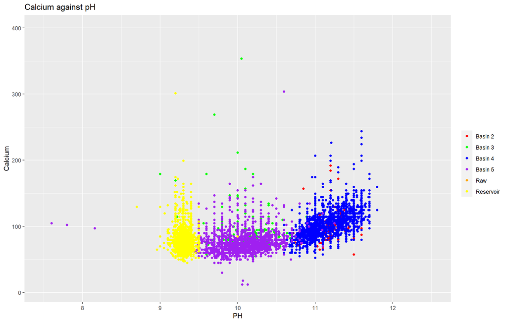

```r
 ggplot() +
    geom_point(data = basin2, aes(x=PH, y = Calcium, color='Basin 2')) +
    geom_point(data = basin3, aes(x=PH, y = Calcium, color='Basin 3')) +
    geom_point(data = basin4, aes(x=PH, y = Calcium, color='Basin 4')) +
    geom_point(data = basin5, aes(x=PH, y = Calcium, color='Basin 5')) +
    geom_point(data = reservoir, aes(x=PH, y = Calcium, color='Reservoir')) +
    geom_point(data = raw_water, aes(x=PH, y = Total.Calcium, color='Raw')) +
    scale_colour_manual("",
                      breaks = c("Basin 2", "Basin 3", "Basin 4", "Basin 5", "Raw", "Reservoir"),
                      values = c("red", "green", "blue", "purple", "orange", "yellow")) +
   ggtitle("Calcium against pH")+
   xlim(7.5, 12.5)+
   ylim(5, 400)
```

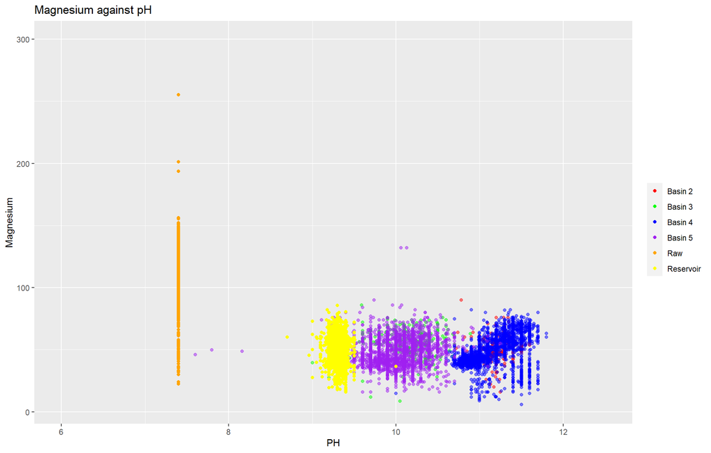

```r
ggplot() +
    geom_point(data = basin2, aes(x=PH, y = Magnesium, color='Basin 2'), alpha=0.5) +
    geom_point(data = basin3, aes(x=PH, y = Magnesium, color='Basin 3'), alpha=0.5) +
    geom_point(data = basin4, aes(x=PH, y = Magnesium, color='Basin 4'), alpha=0.5) +
    geom_point(data = basin5, aes(x=PH, y = Magnesium, color='Basin 5'), alpha=0.5) +
    geom_point(data = reservoir, aes(x=PH, y = Magnesium, color='Reservoir')) +
    geom_point(data = raw_water, aes(x=PH, y = Total.Magnesium, color='Raw')) +
    scale_colour_manual("",
                      breaks = c("Basin 2", "Basin 3", "Basin 4", "Basin 5", "Raw", "Reservoir"),
                      values = c("red", "green", "blue", "purple", "orange", "yellow")) +
   ggtitle("Magnesium against pH")+
   xlim(6, 12.5)+
   ylim(5,300)
```

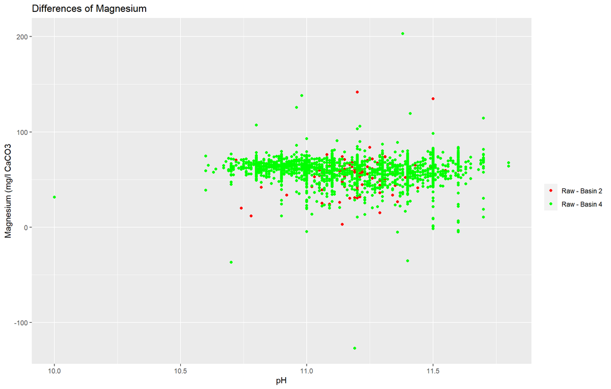

```r
################################################################################################
Basin_2 <- cbind.data.frame(as.Date(basin2$Collection.Date.Time, format = "%m/%d/%Y %H:%M") , basin2$Magnesium)
Basin_2 <- cbind.data.frame(Basin_2 , basin2$PH)
colnames(Basin_2) <- c("Date", "Magnesium_B2", "pH_B2")

Basin_4 <- cbind.data.frame(as.Date(basin4$Collection.Date.Time, format = "%m/%d/%Y %H:%M"), basin4$Magnesium)
Basin_4 <- cbind.data.frame(Basin_4 , basin4$PH)
colnames(Basin_4) <- c("Date", "Magnesium_B4","pH_B4")

Raw <- cbind.data.frame(as.POSIXct(raw_water$Collection.Date.Time,format = "%m/%d/%Y %H:%M"), raw_water$Total.Magnesium)
Raw <- cbind.data.frame(Raw , raw_water$pH)
colnames(Raw) <- c("Date", "Magnesium_R", "pH_R")

data1 <- left_join(Basin_2, Raw, by = "Date")
data2 <- left_join(Basin_4, Raw, by = "Date")
data1[data1 == 0] <- NA
data2[data2 == 0] <- NA

data1 <- data1[complete.cases(data1), ]
data2 <- data2[complete.cases(data2), ]

data1$Difference <- data1$Magnesium_R - data1$Magnesium_B2
data2$Difference <- data2$Magnesium_R - data2$Magnesium_B4
################################################################################################
 ggplot() +
  geom_point(data = data1, aes(x = pH_B2, y = Difference, color = "Raw - Basin 2")) +
  geom_point(data = data2, aes(x = pH_B4, y = Difference, color = "Raw - Basin 4")) +
  scale_colour_manual("",
                      breaks = c("Raw - Basin 2", "Raw - Basin 4"),
                      values = c("red", "green"))+
  xlab('pH') +
  ylab('Magnesium (mg/l CaCO3')+
  ggtitle('Differences of Magnesium')
```

```r
################################################################################################
```

This plots a boxplot of the calcium and magnesium concentrations separated by location.

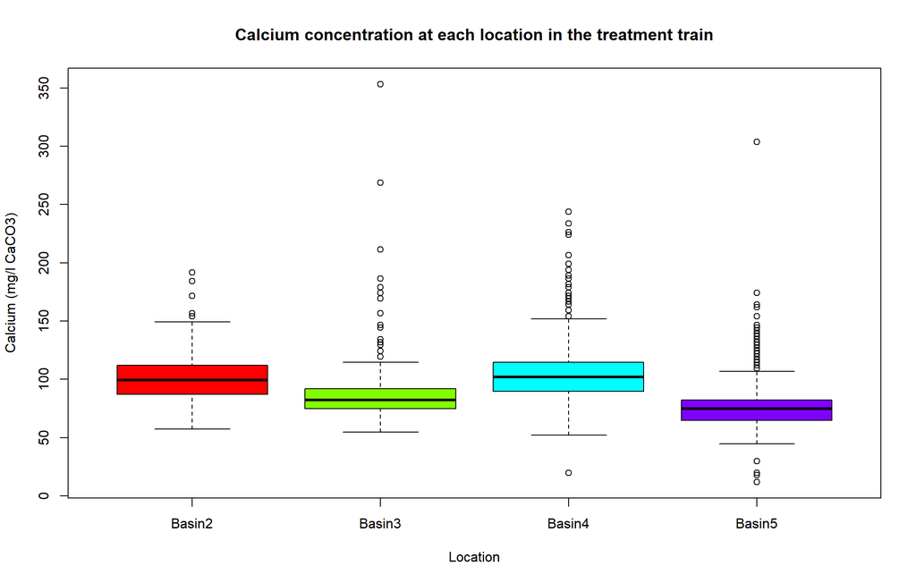

```r
all_data <- bind_rows(basin2, basin3)
all_data <- bind_rows(all_data, basin4)
all_data <- bind_rows(all_data, basin5)
all_data <- bind_rows(all_data, raw_water)
data <- data.frame()
data <- cbind(all_data$Location.description, all_data$Collection.Date.Time)
data <- cbind(data, all_data$Calcium)
data <- cbind(data, all_data$Magnesium)
data <- as.data.frame(data)
colnames(data) <- c("Location", "Date", "Calcium", "Magnesium")
data$Location <- as.factor(data$Location)
data$Calcium <- as.numeric(data$Calcium)
data$Magnesium <- as.numeric(data$Magnesium)
data$Date <- as.POSIXct(data$Date,format="%m/%d/%Y %H:%M",tz=Sys.timezone())
data[data == 0] <- NA

boxplot(data$Calcium~data$Location, col=rainbow(4),
        main = "Calcium concentration at each location in the treatment train",
           xlab = "Location",
           ylab = "Calcium (mg/l CaCO3)")
```

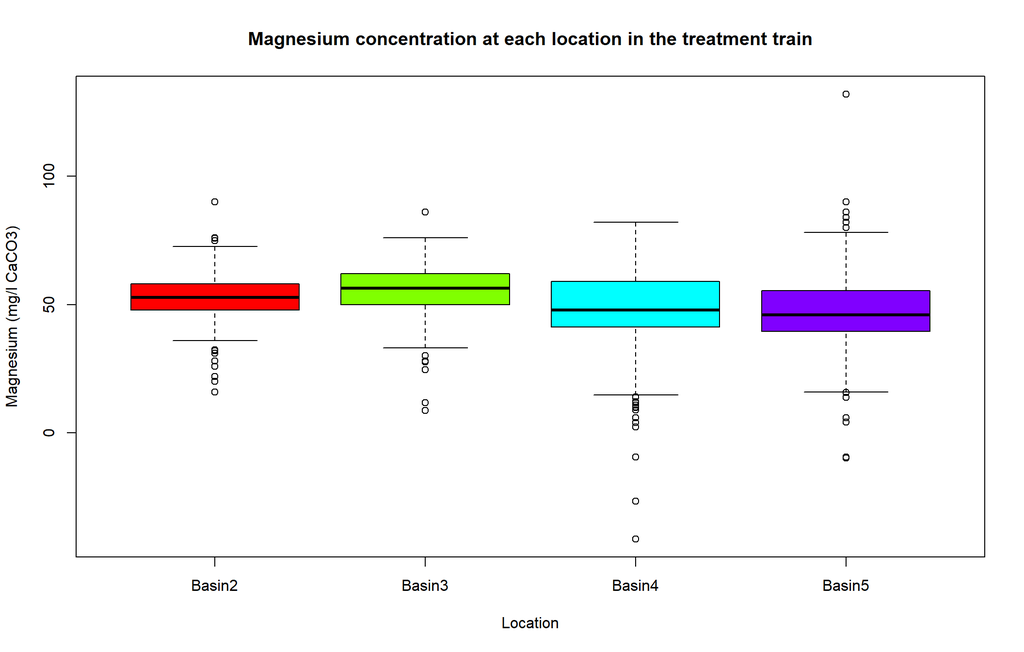

```r
boxplot(data$Magnesium~data$Location, col=rainbow(4),
        main = "Magnesium concentration at each location in the treatment train",
           xlab = "Location",
           ylab = "Magnesium (mg/l CaCO3)")
```

This plots a boxplot of the hardness at each location.

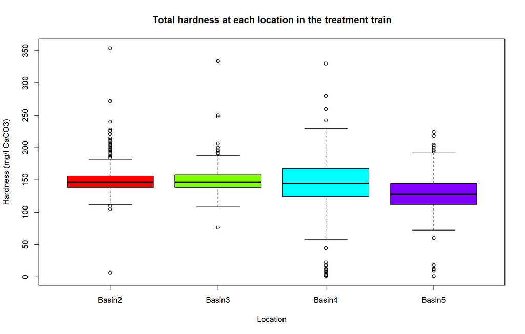

```r
all_data <- bind_rows(basin2, basin3)
all_data <- bind_rows(all_data, basin4)
all_data <- bind_rows(all_data, basin5)
all_data <- bind_rows(all_data, raw_water)
data <- data.frame()
data <- cbind(all_data$Location.description, all_data$Collection.Date.Time)
data <- cbind(data, all_data$Hardness)
data <- as.data.frame(data)
colnames(data) <- c("Location", "Date", "Hardness")
data$Location <- as.factor(data$Location)
data$Hardness <- as.numeric(data$Hardness)
data$Date <- as.POSIXct(data$Date,format="%m/%d/%Y %H:%M",tz=Sys.timezone())
data[data == 0] <- NA

boxplot(data$Hardness~data$Location, col=rainbow(4),
        main = "Total hardness at each location in the treatment train",
           xlab = "Location",
           ylab = "Hardness (mg/l CaCO3)")
```

This plots all locations hardness over time.

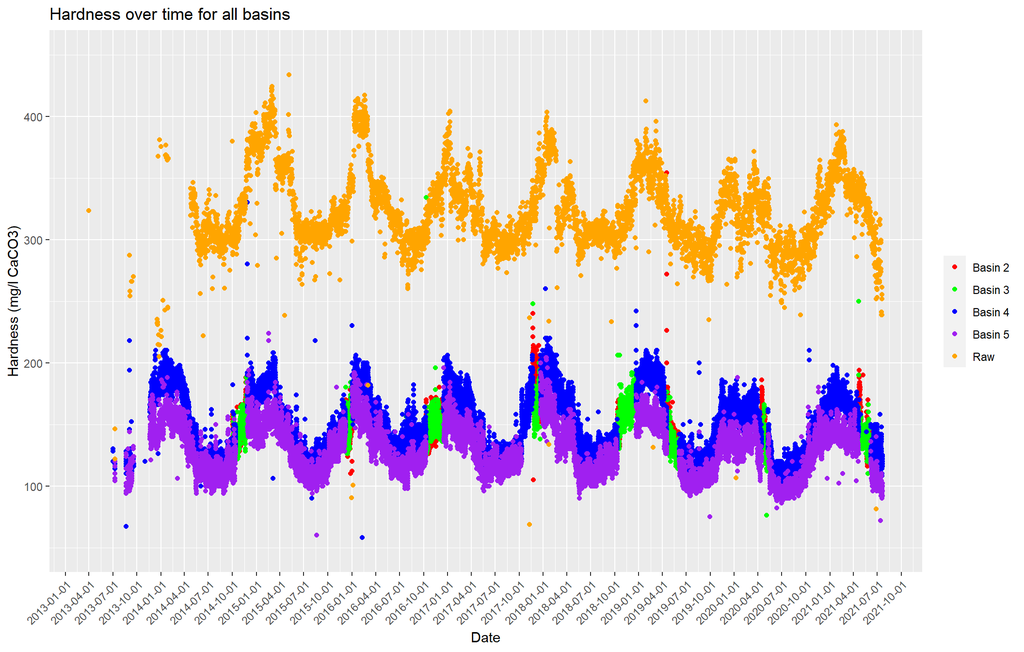

```r
ggplot() +
  geom_point(data = basin2, aes(x=Collection.Date.Time, y = Hardness, color='Basin 2')) +
    geom_point(data = basin3, aes(x=Collection.Date.Time, y = Hardness, color='Basin 3')) +
    geom_point(data = basin4, aes(x=Collection.Date.Time, y = Hardness, color='Basin 4')) +
    geom_point(data = basin5, aes(x=Collection.Date.Time, y = Hardness, color='Basin 5')) +
    geom_point(data = raw_water, aes(x=Collection.Date.Time, y = Total.Hardness, color='Raw')) +
    scale_colour_manual("",
                      breaks = c("Basin 2", "Basin 3", "Basin 4", "Basin 5", "Raw"),
                      values = c("red", "green", "blue", "purple", "orange")) +
  ylim(50, 450)+
  theme(axis.text.x = element_text(angle = 45, vjust = 1, hjust=1))+
  scale_x_datetime(date_breaks = "3 months")+
  xlab('Date') +
  ylab('Hardness (mg/l CaCO3)') +
  ggtitle('Hardness over time for all basins')
```

This plots the hardness removed by each basin over time. Also plots for each individual year.

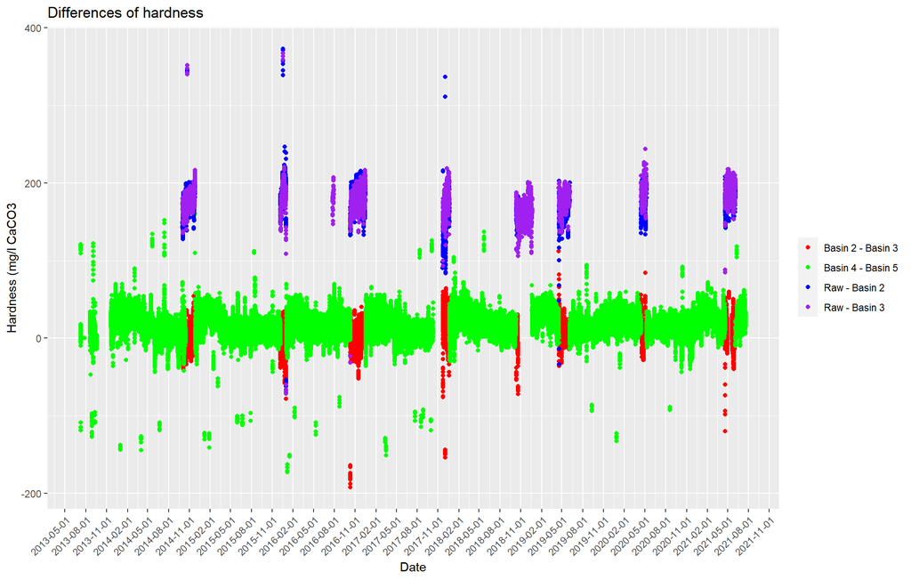

```r
Basin_2 <- cbind.data.frame(as.Date(basin2$Collection.Date.Time, format = "%m/%d/%Y %H:%M") , basin2$Hardness)
colnames(Basin_2) <- c("Date", "Hardness_B2")
Basin_3 <- cbind.data.frame(as.Date(basin3$Collection.Date.Time, format = "%m/%d/%Y %H:%M"), basin3$Hardness)
colnames(Basin_3) <- c("Date", "Hardness_B3")
Basin_4 <- cbind.data.frame(as.Date(basin4$Collection.Date.Time, format = "%m/%d/%Y %H:%M"), basin4$Hardness)
colnames(Basin_4) <- c("Date", "Hardness_B4")
Basin_5 <- cbind.data.frame(as.Date(basin5$Collection.Date.Time, format = "%m/%d/%Y %H:%M"), basin5$Hardness)
colnames(Basin_5) <- c("Date", "Hardness_B5")
Raw <- cbind.data.frame(as.POSIXct(raw_water$Collection.Date.Time,format = "%m/%d/%Y %H:%M"), raw_water$Total.Hardness)
colnames(Raw) <- c("Date", "Hardness_R")

data1 <- left_join(Basin_2, Basin_3, by = "Date")
data2 <- left_join(Basin_4, Basin_5, by = "Date")
data3 <- left_join(Basin_2, Raw, by = "Date")
data4 <- left_join(Basin_3, Raw, by = "Date")
data1[data1 == 0] <- NA
data2[data2 == 0] <- NA
data3[data3 == 0] <- NA
data4[data4 == 0] <- NA
data1 <- data1[complete.cases(data1), ]
data2 <- data2[complete.cases(data2), ]
data3 <- data3[complete.cases(data3), ]
data4 <- data4[complete.cases(data4), ]

data1$Difference <- data1$Hardness_B2 - data1$Hardness_B3
data2$Difference <- data2$Hardness_B4 - data2$Hardness_B5
data3$Difference <- data3$Hardness_R - data3$Hardness_B2
data4$Difference <- data4$Hardness_R - data4$Hardness_B3

data1$Date <- as.POSIXct(data1$Date)
data2$Date <- as.POSIXct(data2$Date)
data3$Date <- as.POSIXct(data3$Date)
data4$Date <- as.POSIXct(data4$Date)

####################################################################################################
ggplot() +
  geom_point(data = data1, aes(x = Date, y = Difference, color = "Basin 2 - Basin 3")) +
  geom_point(data = data2, aes(x = Date, y = Difference, color = "Basin 4 - Basin 5")) +
  geom_point(data = data3, aes(x = Date, y = Difference, color = "Raw - Basin 2")) +
  geom_point(data = data4, aes(x = Date, y = Difference, color = "Raw - Basin 3")) +
  scale_colour_manual("",
                      breaks = c("Basin 2 - Basin 3", "Basin 4 - Basin 5" ,"Raw - Basin 2", "Raw - Basin 3" ),
                      values = c("red", "green", "blue", "purple")) +
  theme(axis.text.x = element_text(angle = 45, vjust = 1, hjust=1))+
  scale_x_datetime(date_breaks = "3 months")+
  xlab('Date') +
  ylab('Hardness (mg/l CaCO3')+
  ggtitle('Differences of hardness')
```

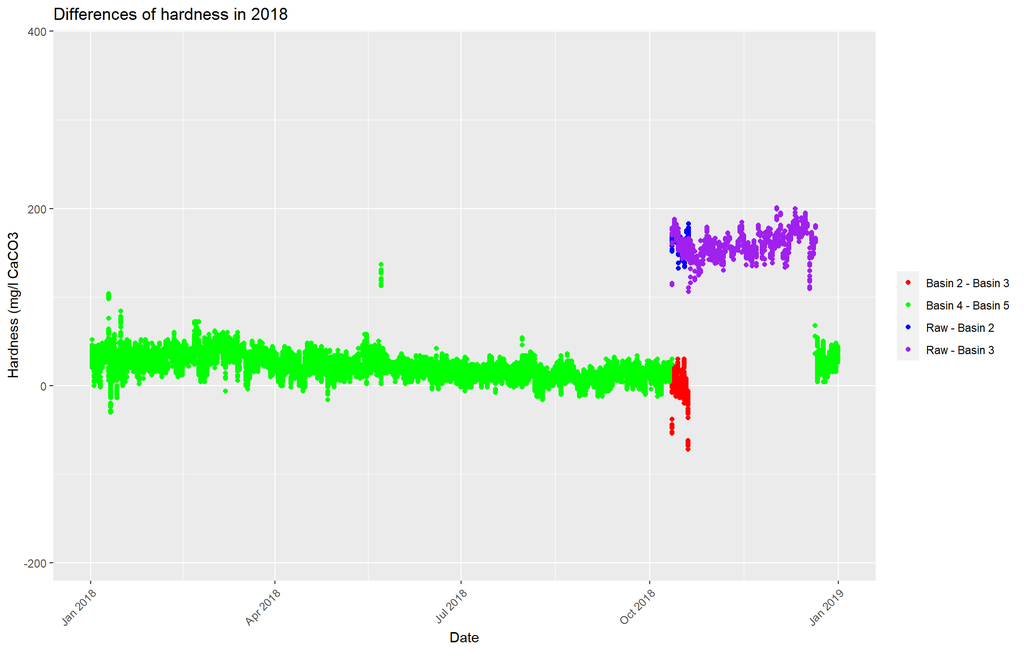

```r
####################################################################################################
ggplot() +
  geom_point(data = data1, aes(x = Date, y = Difference, color = "Basin 2 - Basin 3")) +
  geom_point(data = data2, aes(x = Date, y = Difference, color = "Basin 4 - Basin 5")) +
  geom_point(data = data3, aes(x = Date, y = Difference, color = "Raw - Basin 2")) +
  geom_point(data = data4, aes(x = Date, y = Difference, color = "Raw - Basin 3")) +
  scale_colour_manual("",
                      breaks = c("Basin 2 - Basin 3", "Basin 4 - Basin 5" ,"Raw - Basin 2", "Raw - Basin 3" ),
                      values = c("red", "green", "blue", "purple")) +
  theme(axis.text.x = element_text(angle = 45, vjust = 1, hjust=1))+
  scale_x_datetime(date_breaks = "1 month")+
  xlab('Date') +
  ylab('Hardness (mg/l CaCO3')+
  ggtitle('Differences of hardness in 2018')+
  xlim(as.POSIXct('2018-01-01'),as.POSIXct('2019-01-01'))
```

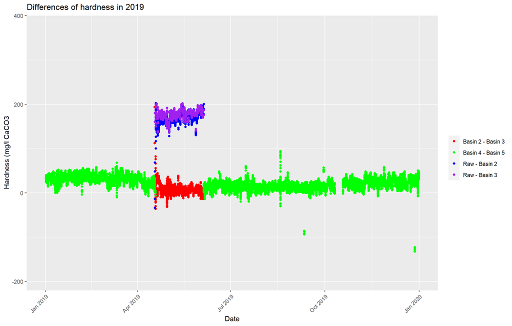

```r
#####################################################################################################
ggplot() +
  geom_point(data = data1, aes(x = Date, y = Difference, color = "Basin 2 - Basin 3")) +
  geom_point(data = data2, aes(x = Date, y = Difference, color = "Basin 4 - Basin 5")) +
  geom_point(data = data3, aes(x = Date, y = Difference, color = "Raw - Basin 2")) +
  geom_point(data = data4, aes(x = Date, y = Difference, color = "Raw - Basin 3")) +
  scale_colour_manual("",
                      breaks = c("Basin 2 - Basin 3", "Basin 4 - Basin 5" ,"Raw - Basin 2", "Raw - Basin 3" ),
                      values = c("red", "green", "blue", "purple")) +
  theme(axis.text.x = element_text(angle = 45, vjust = 1, hjust=1))+
  scale_x_datetime(date_breaks = "1 month")+
  xlab('Date') +
  ylab('Hardness (mg/l CaCO3')+
  ggtitle('Differences of hardness in 2019')+
  xlim(as.POSIXct('2019-01-01'),as.POSIXct('2020-01-01'))
```

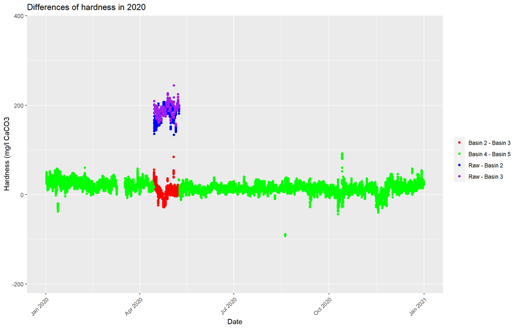

```r
#####################################################################################################
ggplot() +
  geom_point(data = data1, aes(x = Date, y = Difference, color = "Basin 2 - Basin 3")) +
  geom_point(data = data2, aes(x = Date, y = Difference, color = "Basin 4 - Basin 5")) +
  geom_point(data = data3, aes(x = Date, y = Difference, color = "Raw - Basin 2")) +
  geom_point(data = data4, aes(x = Date, y = Difference, color = "Raw - Basin 3")) +
  scale_colour_manual("",
                      breaks = c("Basin 2 - Basin 3", "Basin 4 - Basin 5" ,"Raw - Basin 2", "Raw - Basin 3" ),
                      values = c("red", "green", "blue", "purple")) +
  theme(axis.text.x = element_text(angle = 45, vjust = 1, hjust=1))+
  scale_x_datetime(date_breaks = "1 month")+
  xlab('Date') +
  ylab('Hardness (mg/l CaCO3')+
  ggtitle('Differences of hardness in 2020')+
  xlim(as.POSIXct('2020-01-01'),as.POSIXct('2021-01-01'))
```

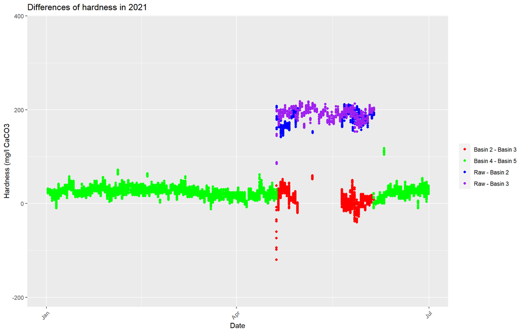

```r
#####################################################################################################
ggplot() +
  geom_point(data = data1, aes(x = Date, y = Difference, color = "Basin 2 - Basin 3")) +
  geom_point(data = data2, aes(x = Date, y = Difference, color = "Basin 4 - Basin 5")) +
  geom_point(data = data3, aes(x = Date, y = Difference, color = "Raw - Basin 2")) +
  geom_point(data = data4, aes(x = Date, y = Difference, color = "Raw - Basin 3")) +
  scale_colour_manual("",
                      breaks = c("Basin 2 - Basin 3", "Basin 4 - Basin 5" ,"Raw - Basin 2", "Raw - Basin 3" ),
                      values = c("red", "green", "blue", "purple")) +
  theme(axis.text.x = element_text(angle = 45, vjust = 1, hjust=1))+
  scale_x_datetime(date_breaks = "1 month")+
  xlab('Date') +
  ylab('Hardness (mg/l CaCO3')+
  ggtitle('Differences of hardness in 2021')+
  xlim(as.POSIXct('2021-01-01'),as.POSIXct('2021-07-01'))
```

```r
#####################################################################################################
```

This plots the difference in hardness between basin 5 and 4, the alkalinity of both basins, the pH of both basins, and the temperature of the reservoir. Also plots for each individual year.

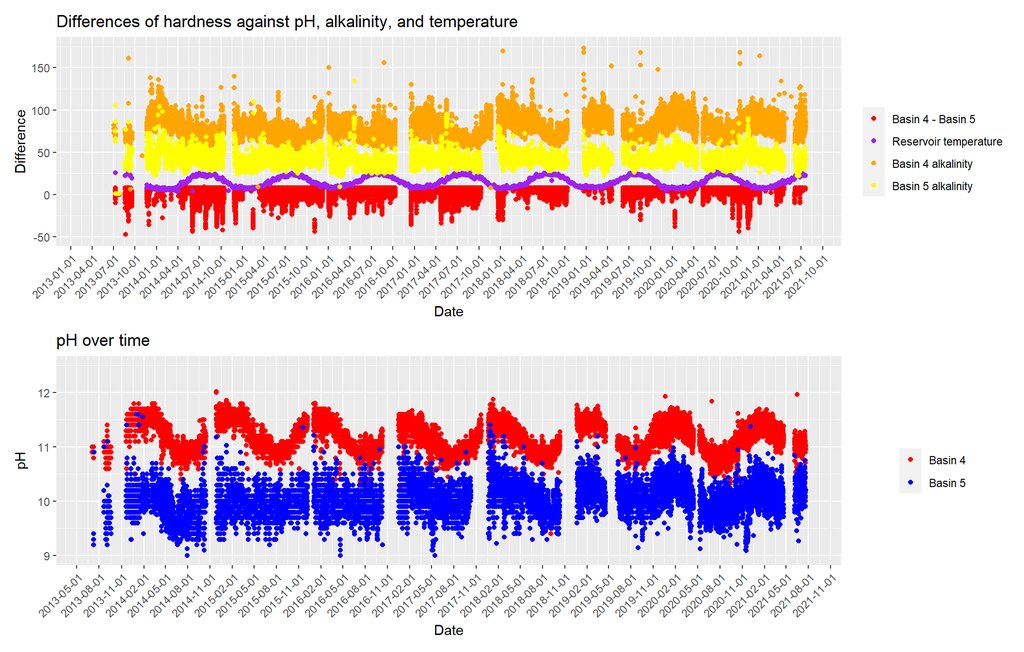

```r
data2.bel10 <- subset(data2, Difference < 10)
reservoir$TEMP_C <- as.numeric(reservoir$TEMP_C)
reservoir_T <- cbind.data.frame(as.POSIXct(reservoir$Collection.Date.Time, format = "%m/%d/%Y %H:%M") , reservoir$TEMP_C)
reservoir_T[reservoir_T == 0] <- NA
basin4[basin4 == 0] <- NA
basin5[basin5 == 0] <- NA
colnames(reservoir_T) <- c("Date", "Temp")
##################################################################################################### All data
plot1 <- ggplot() +
  geom_point(data = data2.bel10, aes(x = Date, y = Difference, color = "Basin 4 - Basin 5")) +

  geom_point(data = reservoir_T, aes(x = Date, y = Temp, color = "Reservoir temperature")) +
  geom_point(data = basin4, aes(x = Collection.Date.Time, y = ALK_TOTAL, color = "Basin 4 alkalinity")) +
  geom_point(data = basin5, aes(x = Collection.Date.Time, y = ALK_TOTAL, color = "Basin 5 alkalinity")) +
  scale_colour_manual("",
                      breaks = c("Basin 4 - Basin 5", "Reservoir temperature", "Basin 4 alkalinity", "Basin 5 alkalinity" ),
                      values = c("red", "purple", "orange", "yellow")) +
  theme(axis.text.x = element_text(angle = 45, vjust = 1, hjust=1))+
  scale_x_datetime(date_breaks = "3 months")+
  xlab('Date') +
  ylim(-50, 175)+
  ggtitle('Differences of hardness against pH, alkalinity, and temperature')

plot2 <- ggplot() +
  geom_point(data = basin4, aes(x = Collection.Date.Time, y = PH, color = "Basin 4")) +
  geom_point(data = basin5, aes(x = Collection.Date.Time, y = PH, color = "Basin 5")) +
  scale_colour_manual("",
                      breaks = c("Basin 4", "Basin 5"),
                      values = c("red","blue")) +
  theme(axis.text.x = element_text(angle = 45, vjust = 1, hjust=1))+
  scale_x_datetime(date_breaks = "3 months")+
  xlab('Date') +
  ylab('pH')+
  ylim(9,12.5)+
  ggtitle('pH over time')

plot1/plot2
```

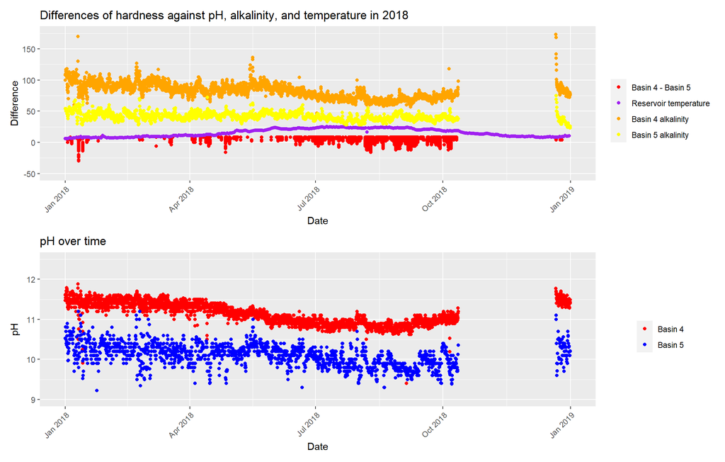

```r
##################################################################################################### For 2018
plot1 <- ggplot() +
  geom_point(data = data2.bel10, aes(x = Date, y = Difference, color = "Basin 4 - Basin 5")) +

  geom_point(data = reservoir_T, aes(x = Date, y = Temp, color = "Reservoir temperature")) +
  geom_point(data = basin4, aes(x = Collection.Date.Time, y = ALK_TOTAL, color = "Basin 4 alkalinity")) +
  geom_point(data = basin5, aes(x = Collection.Date.Time, y = ALK_TOTAL, color = "Basin 5 alkalinity")) +
  scale_colour_manual("",
                      breaks = c("Basin 4 - Basin 5", "Reservoir temperature", "Basin 4 alkalinity", "Basin 5 alkalinity" ),
                      values = c("red", "purple", "orange", "yellow")) +
  theme(axis.text.x = element_text(angle = 45, vjust = 1, hjust=1))+
  ##scale_x_datetime(date_breaks = "3 months")+
  xlab('Date') +
  ggtitle('Differences of hardness against pH, alkalinity, and temperature in 2018')+
  ylim(-50, 175)+
  xlim(as.POSIXct('2018-01-01'),as.POSIXct('2019-01-01'))

plot2 <- ggplot() +
  geom_point(data = basin4, aes(x = Collection.Date.Time, y = PH, color = "Basin 4")) +
  geom_point(data = basin5, aes(x = Collection.Date.Time, y = PH, color = "Basin 5")) +
  scale_colour_manual("",
                      breaks = c("Basin 4", "Basin 5"),
                      values = c("red","blue")) +
  theme(axis.text.x = element_text(angle = 45, vjust = 1, hjust=1))+
  ##scale_x_datetime(date_breaks = "3 months")+
  xlab('Date') +
  ylab('pH')+
  ylim(9,12.5)+
  ggtitle('pH over time')+
  xlim(as.POSIXct('2018-01-01'),as.POSIXct('2019-01-01'))

plot1/plot2
```

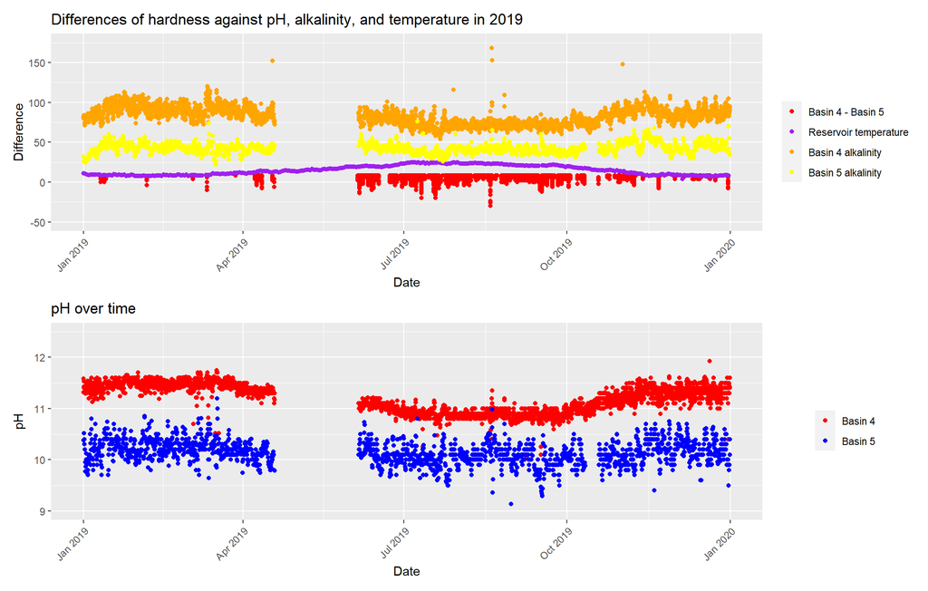

```r
##################################################################################################### For 2019
plot1 <- ggplot() +
  geom_point(data = data2.bel10, aes(x = Date, y = Difference, color = "Basin 4 - Basin 5")) +

  geom_point(data = reservoir_T, aes(x = Date, y = Temp, color = "Reservoir temperature")) +
  geom_point(data = basin4, aes(x = Collection.Date.Time, y = ALK_TOTAL, color = "Basin 4 alkalinity")) +
  geom_point(data = basin5, aes(x = Collection.Date.Time, y = ALK_TOTAL, color = "Basin 5 alkalinity")) +
  scale_colour_manual("",
                      breaks = c("Basin 4 - Basin 5", "Reservoir temperature", "Basin 4 alkalinity", "Basin 5 alkalinity" ),
                      values = c("red", "purple", "orange", "yellow")) +
  theme(axis.text.x = element_text(angle = 45, vjust = 1, hjust=1))+
  ##scale_x_datetime(date_breaks = "3 months")+
  xlab('Date') +
  ggtitle('Differences of hardness against pH, alkalinity, and temperature in 2019')+
  ylim(-50, 175)+
  xlim(as.POSIXct('2019-01-01'),as.POSIXct('2020-01-01'))

plot2 <- ggplot() +
  geom_point(data = basin4, aes(x = Collection.Date.Time, y = PH, color = "Basin 4")) +
  geom_point(data = basin5, aes(x = Collection.Date.Time, y = PH, color = "Basin 5")) +
  scale_colour_manual("",
                      breaks = c("Basin 4", "Basin 5"),
                      values = c("red","blue")) +
  theme(axis.text.x = element_text(angle = 45, vjust = 1, hjust=1))+
  ##scale_x_datetime(date_breaks = "3 months")+
  xlab('Date') +
  ylab('pH')+
  ylim(9,12.5)+
  ggtitle('pH over time')+
  xlim(as.POSIXct('2019-01-01'),as.POSIXct('2020-01-01'))

plot1/plot2
```

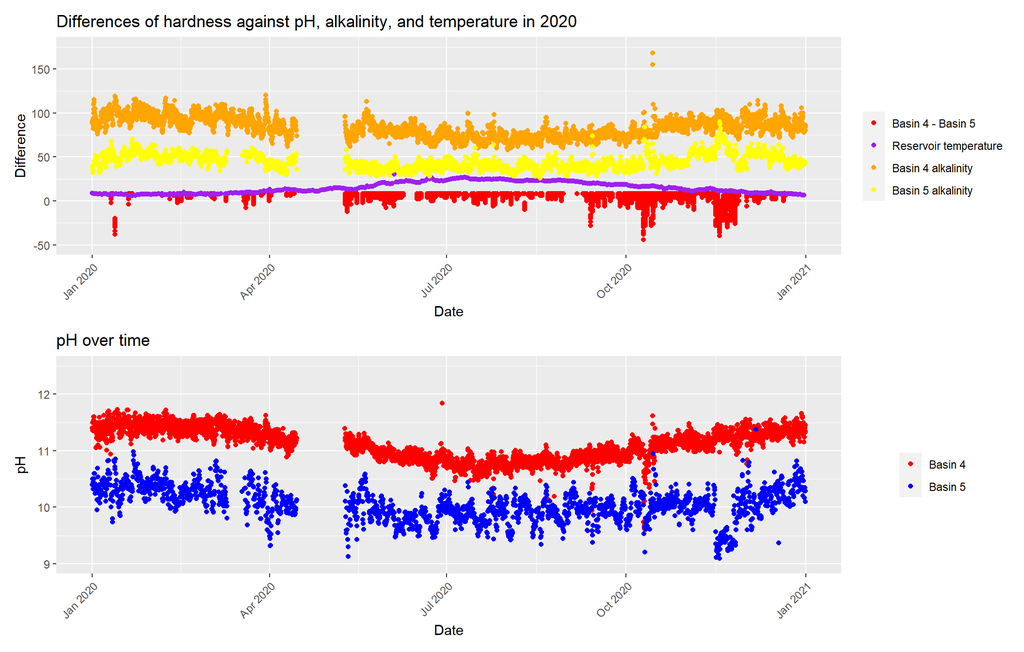

```r
##################################################################################################### For 2020
plot1 <- ggplot() +
  geom_point(data = data2.bel10, aes(x = Date, y = Difference, color = "Basin 4 - Basin 5")) +

  geom_point(data = reservoir_T, aes(x = Date, y = Temp, color = "Reservoir temperature")) +
  geom_point(data = basin4, aes(x = Collection.Date.Time, y = ALK_TOTAL, color = "Basin 4 alkalinity")) +
  geom_point(data = basin5, aes(x = Collection.Date.Time, y = ALK_TOTAL, color = "Basin 5 alkalinity")) +
  scale_colour_manual("",
                      breaks = c("Basin 4 - Basin 5", "Reservoir temperature", "Basin 4 alkalinity", "Basin 5 alkalinity" ),
                      values = c("red", "purple", "orange", "yellow")) +
  theme(axis.text.x = element_text(angle = 45, vjust = 1, hjust=1))+
 ## scale_x_datetime(date_breaks = "3 months")+
  xlab('Date') +
  ggtitle('Differences of hardness against pH, alkalinity, and temperature in 2020')+
  ylim(-50, 175)+
  xlim(as.POSIXct('2020-01-01'),as.POSIXct('2021-01-01'))

plot2 <- ggplot() +
  geom_point(data = basin4, aes(x = Collection.Date.Time, y = PH, color = "Basin 4")) +
  geom_point(data = basin5, aes(x = Collection.Date.Time, y = PH, color = "Basin 5")) +
  scale_colour_manual("",
                      breaks = c("Basin 4", "Basin 5"),
                      values = c("red","blue")) +
  theme(axis.text.x = element_text(angle = 45, vjust = 1, hjust=1))+
  ##scale_x_datetime(date_breaks = "3 months")+
  xlab('Date') +
  ylab('pH')+
  ylim(9,12.5)+
  ggtitle('pH over time')+
  xlim(as.POSIXct('2020-01-01'),as.POSIXct('2021-01-01'))

plot1/plot2
```